# Lab 1 - Basic R syntax/plots with data solutions

Ryan Yancey

### For this lab, we will be using some basic data manipulation and plotting commands in R. We are working with a data set that is comparing the transcript profiles from peripheral B lymphocytes between patients with systemic lupus erythematosus (SLE) and normal healthy controls. The [GEO summary](https://www.ncbi.nlm.nih.gov/geo/query/acc.cgi?acc=GSE30153) of the data set is as follows:

> Systemic lupus erythematosus (SLE) is an autoimmune disease with an important clinical and biological heterogeneity. B lymphocytes appear central to the development of SLE which is characterized by the production of a large variety of autoantibodies and hypergammaglobulinemia. In mice, immature B cells from spontaneous lupus prone animals are able to produce autoantibodies when transferred into immunodeficient mice, strongly suggesting the existence of intrinsic B cell defects during lupus. In order to approach these defects in humans, we compared the peripheral B cell transcriptomes of quiescent lupus patients to normal B cell transcriptomes.

**1.) Go to class website under Course Documents > Data Sets and download the SLE B cell data set (from Garaud et al).**

Done. Downloaded data set as **sle_b_cell.7z** in my working directory.  
**2.) Unzip the text file, and read into R (Hint: using the `read.table()` function with a `header = T` argument and `row.names = 1` argument is one method to do this).**

After downloading the file, we’ll look at my directory to see what files are available to work with.

```r
dir()
```

```
## [1] "gedav-lab1.Rmd"   "gedav-lab1.Rproj" "lab-1.pdf"        "sle_b_cell.7z"
```

We’re interested in working with **sle_b_cell.7z** but we need to extract its contents first. We can do this by using the 7zip extractor, p7zip. I’m on a UNIX system, so I’ll run the command in R as I would in my terminal, but modified to work within R.

```r
# decompress sle_b_cell.7z
system(command = "7z -y e sle_b_cell.7z")

# view the new file in directory
dir()
```

```
## [1] "gedav-lab1.Rmd"   "gedav-lab1.Rproj" "lab-1.pdf"        "sle_b_cell.7z"
## [5] "sle_b_cell.txt"
```

Now, we can import **sle_b_cell.txt** into our environment.

```r
# read data into R
garaud <- read.table(file = "sle_b_cell.txt",
                  header = TRUE,
                  row.names = 1)

# view the first few rows to preview data
head(x = garaud)
```

```
##              sle.1    sle.2    sle.3    sle.4    sle.5    sle.6    sle.7
## 1007_s_at 7.201054 6.946044 6.722417 6.478136 7.657807 7.458431 7.128307
## 1053_at   6.329305 6.525640 6.323421 5.788303 7.064163 6.475584 6.394097
## 117_at    4.943542 4.075428 5.173628 5.161637 5.879714 5.207273 4.860286
## 121_at    5.964546 5.959280 5.956043 5.891120 6.207989 6.155414 5.936915
## 1294_at   8.798413 9.027502 9.478432 9.069233 9.210925 9.060505 8.605030
## 1316_at   4.272086 3.659428 3.673992 3.822420 3.735879 4.164235 3.724233
##              sle.8    sle.9   sle.10   sle.11   sle.12   sle.13   sle.14
## 1007_s_at 6.893233 7.417972 6.931443 7.043239 6.477673 7.257562 7.196866
## 1053_at   6.708787 6.457130 6.407173 6.124894 6.181405 6.471388 6.504525
## 117_at    4.589202 5.545966 5.397000 5.204737 5.510464 5.551032 4.594924
## 121_at    5.647587 6.175860 5.905099 5.619636 5.917675 6.130143 5.899389
## 1294_at   9.088856 9.002307 9.386652 9.434617 9.329697 8.469365 8.794065
## 1316_at   3.669170 4.107480 3.806881 3.715541 3.825745 3.875756 3.803949
##             sle.15   sle.16   sle.17 control.1 control.2 control.3 control.4
## 1007_s_at 7.215563 6.975056 6.946701  7.001722  7.674048  7.207480  7.237135
## 1053_at   6.638673 6.619250 6.427475  6.417270  6.583484  6.304779  6.631808
## 117_at    4.974176 4.452682 4.879310  6.204755  5.462083  5.162292  5.182004
## 121_at    6.665831 6.567842 5.931885  5.819153  5.634927  6.063086  5.618122
## 1294_at   9.255156 9.297987 8.527558  9.156431  9.028355  9.878348  8.880848
## 1316_at   3.870495 3.978532 4.068268  3.889457  3.725608  4.024489  3.778687
##           control.5 control.6 control.7 control.8 control.9
## 1007_s_at  6.819833  7.261240  6.934885  7.003605  7.275157
## 1053_at    6.496153  6.584563  6.376337  6.355599  6.419475
## 117_at     5.214210  4.657415  5.199447  5.796467  4.687595
## 121_at     5.627996  6.050202  5.744575  6.366819  5.910187
## 1294_at    9.025513  8.503446  8.619609  9.285734  8.710406
## 1316_at    3.826248  3.826856  3.811117  3.990947  3.830298
```

Each row appears to be a probeset in the microarray, and each column appears to be a sample from the experiment.

**3.) Look at the dimensions of the garaud. There should be 26 samples. If you have 27 samples, you still have the row names in the first data column, so retry 2 to set the row names to these.**

```r
dim(garaud)
```

```
## [1] 34853    26
```

There’s 34,853 probesets and 26 samples.

**4.) Print the sample names to screen.**

```r
# samples are columns (in tidy data, that is), so we will view that
colnames(garaud)
```

```
##  [1] "sle.1"     "sle.2"     "sle.3"     "sle.4"     "sle.5"     "sle.6"
##  [7] "sle.7"     "sle.8"     "sle.9"     "sle.10"    "sle.11"    "sle.12"
## [13] "sle.13"    "sle.14"    "sle.15"    "sle.16"    "sle.17"    "control.1"
## [19] "control.2" "control.3" "control.4" "control.5" "control.6" "control.7"
## [25] "control.8" "control.9"
```

Of the 26 samples, the first 17 are SLE samples, and the remaining 9 are control samples

**5.) Plot the second SLE patient sample versus the first normal control samples in an xy scatter plot. Remember that the first argument is the x vector. Label the x and y-axes as ‘Normal’ and ‘SLE’, respectively. Title the plot, ‘SLE B cell sample vs. Normal B cell sample – all probesets’. Add grey grid lines with the function `grid()`.**

[figure not shown]

```r
# plot probesets
plot(
    x = garaud[, "sle.2"],
    y = garaud[, "control.1"],
    xlab = "Normal",
    ylab = "SLE",
    main = "SLE B cell sample vs. Normal B cell sample -- all probesets"
)

# add grid to plot
grid()
```

**6.) Now do the same plot but pick only the first 20 probesets. Use the `pch = 15` argument to change the shape and color the points blue with the `col` argument.**

[figure not shown]

```r
# plot probesets
plot(
    # subset rows 1 thru 20
    x = garaud[1:20, "sle.2"],
    y = garaud[1:20, "control.1"],
    xlab = "Normal",
    ylab = "SLE",
    # update title to reflect subset
    main = "SLE B cell sample vs. Normal B cell sample -- first 20 probesets",
    # change shape and color of points
    pch = 15,
    col = "blue"
)

# add grid to plot
grid()
```

**7.) Now plot the following gene in a gene profile plot, IGLJ3 (immunoglobulin lambda joining 3), which is probeset ID 211881_x_at. This type of plot has the sample indices across the x-axis and the intensities on the y-axis, so you can see a profile of the gene across experiments or arrays. First plot the ranges using the `type=”n”` argument and the `plot()` function, then add the genes with the `lines()` function call. Add grid lines. Hint: to plot just ranges of x and y vectors, use the `range()` function like so:**

`plot(range(1:26),range(dat[geneX,]),...`

**Be sure to cast the gene vector to numeric before plotting.**

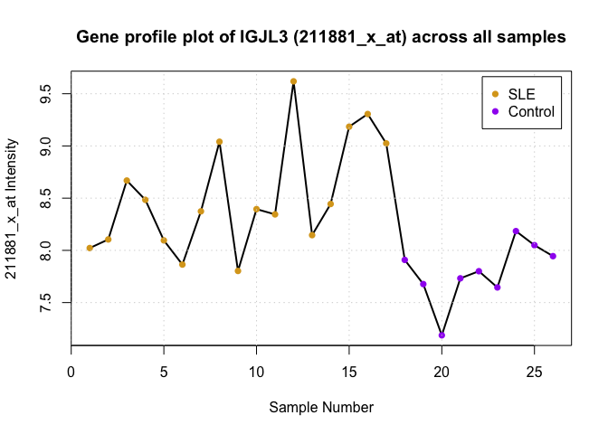

```r
# subset the rows based on the probeset ID
IGJL3_allsamples <- as.numeric(garaud["211881_x_at", ])

# plot an empty canvas with labels
plot(
    x = range(1:26),
    y = range(IGJL3_allsamples),
    type = "n", # empty plot
    xlab = "Sample Number",
    ylab = "211881_x_at Intensity",
    main = "Gene profile plot of IGJL3 (211881_x_at) across all samples"
)

# add line to plot
lines(x = IGJL3_allsamples, lwd = 2)

# add points and color based on sample type (17: SLE, 9: control)
points(
    x = IGJL3_allsamples,
    pch = 16,
    col = c(rep("goldenrod", 17), rep("purple", 9))
)

# add grid to plot
grid()

# add figure legend for clarity
legend(
    "topright",
    bg = "white",
    inset = 0.02,
    legend = c("SLE", "Control"),
    col = c("goldenrod", "purple"),
    pch = 16
)
```

**8.) Finally, another way to visualize a gene profile across conditions is to graph a boxplot with a single distribution box per condition. To do this, we need to create a factor vector that indicates the disease or normal condition like so:**

`f <- c(rep("SLE",17),rep("Control",9))`

**Then use this vector with the expression vector for IGLJ3 in the `boxplot()` function to create the graph.**

```r
# factor vector for samples
samples <- c(rep("SLE", 17), rep("Control", 9))

# create a data frame for the IGJL3 subset with factors included
df.8 <- data.frame(Sample = samples, IGJL3 = IGJL3_allsamples)
```

**Not required, but you can increase the plot info by using the `with()` function and `stripchart()` function to add points.**

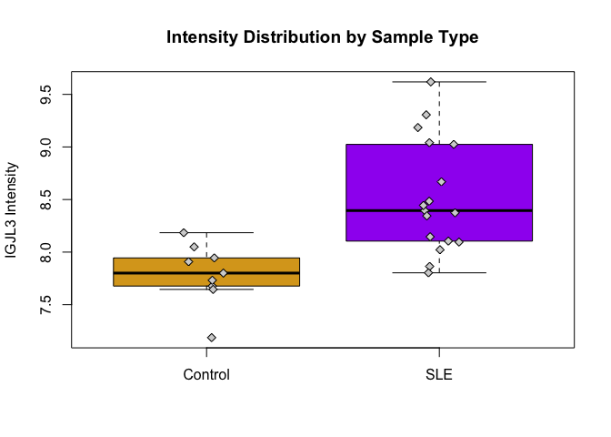

```r
# makes jitter from stripchart reproducible
set.seed(1234)

# plot boxplot and add stripchart on top
with(df.8, {
    boxplot(
        # formula: y ~ group
        IGJL3 ~ Sample,
        col = c("goldenrod", "purple"),
        # remove x-axis label
        xlab = "",
        ylab = "IGJL3 Intensity",
        # make outliers invisible otherwise duplicated by stripchart
        outcol = "white",
        main = "Intensity Distribution by Sample Type"
    )

    # add stripchart on top
    stripchart(
        IGJL3 ~ Sample,
        method = "jitter",
        pch = 23,
        bg = "lightgray",
        vertical = TRUE,
        add = TRUE
    )
})
```